# tme-04

## IA & Data science (LU3IN0226) -- 2025-2026

*© Equipe pédagogique: Christophe Marsala, Olivier Schwander, Jean-Noël Vittaut, Maxellende Julienne.*

*Version du mardi 17 février 2026*

**[Q]** **Indiquer dans la boîte ci-dessous vos noms et prénoms :**

*Double-cliquer ici et insérer les noms et prénoms de votre binôme*

**[Q]** **Renommer ce fichier ipython**

Tout en haut de cette page, cliquer sur `tme-04` et rajouter à la suite de `tme-04` les noms des membres du binômes séparés par un tiret.

IMPORTANT: soumission de votre fichier final

**Nom à donner au fichier à poster** : *tme-04-Nom1_Nom2.ipynb*

- *Nom1* et *Nom2* : noms des membres du binôme
- ne pas compresser ou faire une archive: il faut rendre le notebook tel quel, éventuellement, si vous avez d'autres fichiers vous les rendez séparément.

**Echancier pour la soumission de votre compte-rendu:**

- le compte-rendu d'une séance doit être remis obligatoirement avant la séance suivante de votre groupe.

**Le compte-rendu est soumis sur la page Moodle.**

```python
# - - - - - - - - - - - - - - - - - -
# imports utiles
import numpy as np
import pandas as pd
import matplotlib.pyplot as plt
import matplotlib as mtpl
%matplotlib inline

import math
import time
import sys

# Les instructions suivantes sont utiles pour recharger automatiquement
# le code modifié dans les librairies externes
%load_ext autoreload
%autoreload 2

# - - - - - - - - - - - - - - - - - -
# Information sur l'environnent utilisé ici:
print("Version python et des librairies:")
print("\tPython ",sys.version)
print("\tpandas: ",pd.__version__)
print("\tnumpy: ",np.__version__)
print("\tmatplotlib: ",mtpl.__version__)
```

## Création d'une librairie

Afin de pouvoir réutiliser les classes et fonctions écrites précédemment dans les séances de TDTME, vous allez construire une librairie avec vos fonctions.

Cette librairie, qui s'appellera IADS, contiendra toutes les classes et fonctions que vous allez développer lors de vos séances de TDTME. Elle sera construite donc séance après séance par l'ajout des nouvelles classes et fonctions que vous écrirez.

Important: dans un premier temps, **vous devez écrire les classes et fonctions demandées dans le notebook** de la séance de TDTME courante. A la séance suivante, ou une fois que tout fonctionne correctement, vous rajouterez les classes et fonctions écrites et testées dans vos fichiers de la librairie IADS pour pouvoir réutiliser vos classifieurs par la suite dans les séances suivantes. Attention, lors de la recopie d'un classifieur dans le fichier python de la librairie, il faudra l'adapter.

Récupérer et désarchiver l'archive `iads.tgz` de telle sorte que le répertoire `iads` soit un **répertoire frère** du répertoire `tme04`.

Ainsi, vous devrez avoir une arborescence qui ressemble à ça:

```
- LU3IN026/
    - tme01/
        - tme-01.ipynb
    - tme02/
        - tme-02.ipynb
    - tme03/
        - tme-03.ipynb
    - tme04/
        - tme-04.ipynb
    - iads/
        - Classifiers.py
        - Clustering.py
        - utils.py
        - evaluation.py
        - __init__.py
```

**Important** :

- ce fichier `tme-04.ipynb` doit toujours rester dans le répertoire `tme04/`
- pour ouvrir les fichiers python (extension .py) qui se trouvent dans le répertoire `iads/` il est nécessaire d'utiliser un éditeur de texte comme emacs, gedit, idle,...

**[Q]** **Ouvrir et compléter les fichiers Classifiers.py et utils.py**

Pour compléter ces fichiers, reprendre le code écrit dans les TDTME précédents.

- dans `utils.py`: `genere_dataset_uniform`, `genere_dataset_gaussian`, `genere_train_test`, `plot2DSet`, `plot_frontiere`, `plot2DTrainTestSet` et `create_XOR`
- dans `Classifiers.py`: reprendre le code de tous les classifiers que vous avez définis.

**[Q]** **Mise à jour de la librairie `iads`**

En premier lieu, vérifier que votre librairie `iads` est bien à jour : elle doit maintenant contenir toutes les fonctions et classes que mises au point et testées dans les séances précédentes. Une fois à jour, importer la librairie pour pouvoir l'utiliser dans ce notebook:

```python
# Importation de votre librairie iads:
# La ligne suivante permet de préciser le chemin d'accès à la librairie iads
import sys
sys.path.append('../')   # iads doit être dans le répertoire père du répertoire courant !

# Importation de la librairie iads
import iads as iads

# importation de Classifiers
from iads import Classifiers as cl

# importation de utils
from iads import utils as ut
```

Dans les prochains notebooks, vous mettrez au point les fonctions et classes demandées et une fois qu'elles seront au point et validées, vous les transfèrerez dans votre librairie `IADS` pour pouvoir les réutiliser dans les séances suivantes.

**Attention:** à partir d'ici, lorsque vous voulez utiliser un algorithme qui se trouve dans le fichier `Classifier.py` il est nécessaire de préfixer son nom par `cl.` qui est le nom d'importation de la librairie. Pour utiliser une fonction du fichier `utils.py`, il faut préfixer le nom de la fonction par `ut.`

Dans les boîtes qui vont suivre, on applique ce principe.

```python
# Remarque: si vous ne vous rappelez pas comment utiliser une fonction et si vous avez
# bien documenté votre code, vous pouvez utiliser la fonction help avec le nom de votre fonction:

help(ut.plot2DTrainTestSet)

# celle-ci renvoie le texte indiqué dans les commentaires """ ... """
```

```
Help on function plot2DTrainTestSet in module iadsenseignant.utils:

plot2DTrainTestSet(d_train, l_train, d_test, l_test, nom_dataset='Dataset', avec_grid=True)
    array * array array * array * str * bool-> affichage
    nom_dataset (str): nom du dataset pour la légende
    avec_grid (bool) : True si on veut afficher la grille, False sinon
    la fonction doit utiliser les couleurs suivantes:
    - pour les données d'apprentissage : la couleur 'red' pour la classe -1 et 'blue' pour la +1
    - pour les données de test : la couleur 'jaune' pour la classe -1 et 'verte' pour la +1
```

```
Taille du dataset gaussien généré :(200, 2) exemples
Base d'apprentissage: (150, 2) et 150 labels
Base de test: (50, 2) et 50 labels
```

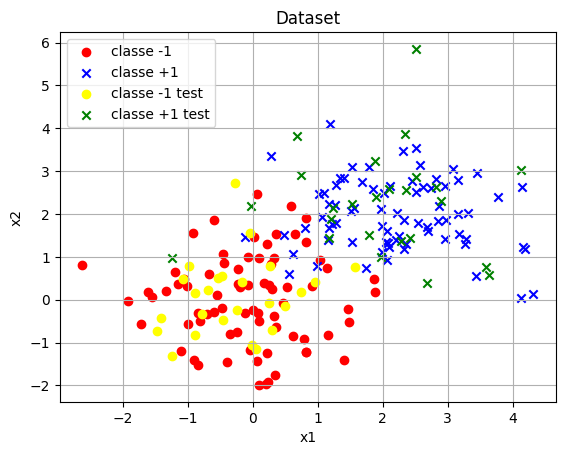

```python
# Exemple d'utilisation:
np.random.seed(42)   # on prend 42 comme graine

# Génération d'un dataset gaussien avec 200 exemples au total
X_gauss, Y_gauss = ut.genere_dataset_gaussian(np.array([2,2]) ,np.array([[1,0],[0,1]]), \
                                                       np.array([0,0]), np.array([[1,0],[0,1]]), \
                                                       100)

print(f"Taille du dataset gaussien généré :{np.shape(X_gauss)} exemples")

# Découpage en train/test du dataset gaussien
(train_desc, train_label), (test_desc, test_label) = ut.genere_train_test(X_gauss, Y_gauss,75,75)

print(f"Base d'apprentissage: {train_desc.shape} et {len(train_label)} labels")
print(f"Base de test: {test_desc.shape} et {len(test_label)} labels")

# Affichage :
ut.plot2DTrainTestSet(train_desc, train_label,test_desc, test_label)
```

**[Q]** Quels sont les centres des gaussiennes utilisées pour générer les exemples dans la boîte précédente ?

Dans ce qui va suivre, on va modifier la classe `ClassifierPerceptron` et l'on souhaite quand même conserver la version écrite au TME3.

Commencez donc par dupliquer la classe `ClassifierPerceptron` déjà écrite (et qui doit correctement fonctionner) et rebaptisez-là `ClassifierPerceptronTME3`, cette classe servira de comparaison avec la nouvelle version de `ClassifierPerceptron` que vous allez écrire.

Après avoir dupliqué la classe, dans `ClassifierPerceptronTME3` modifier les messages affichés dans `__init__` et la chaîne rendue par `__str__` en ajoutant "TME3".

Dans la boîte suivante, on vérifie que cela fonctionne correctement.

```
Classifier #1 (d2): Perceptron (TME3) - init (learning rate= 0.01) w= [-0.00025092  0.00090143]
Apprentissage:
train Classifier #1 (d2) - PerceptronTME3 w= [ 0.0138779, -0.00136537] : 1000 appels à train_step
Accuracy Train:	0.7267
Accuracy Test:	0.7800
```

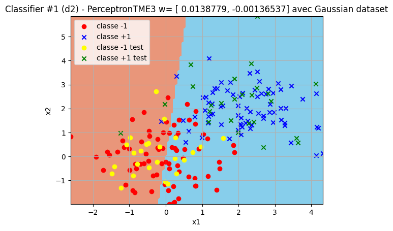

```python
# Réinitialisation de la graine pour la mise au point (à enlever ensuite !)
np.random.seed(42)   # on prend 42 comme graine

# De même, les classes de Classifiers sont utilisables en mettant cl. devant leur nom:
# Création d'un perceptron
perceptronV1 = cl.ClassifierPerceptronTME3(2, learning_rate=0.01, init=False, verbose=True)

print("Apprentissage:")
perceptronV1.train(train_desc,train_label,nb_max=1000,verbose=True)

print(f"Accuracy Train:\t{perceptronV1.accuracy(train_desc,train_label):1.4f}")
print(f"Accuracy Test:\t{perceptronV1.accuracy(test_desc,test_label):1.4f}")

# Affichage de la frontière de séparation des classes
ut.plot_frontiere(X_gauss, Y_gauss,perceptronV1,step=120)
ut.plot2DTrainTestSet(train_desc,train_label,test_desc,test_label, nom_dataset=f"{perceptronV1} avec Gaussian dataset")
```

**[Q]** Sur la figure, on remarque qu'il y a beaucoup d'exemples de la classe $-1$ mal classés, même parmi les données d'apprentissage. Ce résultat était prévisible, pourquoi ? Expliquer ce qui se passe.

## Finalisation du perceptron de Rosenblatt

Dans le cours 3, vous avez vu que la forme générale du perceptron inclus un biais $b$. L'avant-dernière slide du cours 3 donne l'astuce pour intégrer ce bien dans l'algorithme du perceptron:

1. Transformer $w=(w_1, w_2,\ldots,w_d)$ en un nouveau vecteur de poids augmenté $w' = (w_1, w_2,\ldots,w_d, b)$.
2. Transformer $x=(x_1, x_2,\ldots,x_d)$ en un nouveau vecteur augmenté $x' = (x_1, x_2,\ldots,x_d, -1)$.
3. L'algorithme du perceptron s'applique en considérant $x'$ et $w'$.

On va améliorer le classifieur perceptron déjà écrit en incluant un biais grâce à cette façon de faire. Pour cela, on prend la stratégie suivante:

- la variable d'instance `__w` sera augmentée d'une dimension (en fin) pour intégrer le biais
- chaque fois que l'on aura à traiter un exemple $x$, on l'augmentera en lui ajoutant $-1$ en fin.

**[Q]** Dans à la classe `ClassifierPerceptron`,

1. dans la méthode `__init__`,
   - quand l'option de génération des poids à $0$ est choisie, ajouter une dimension supplémentaire à $0$ à $w$;
   - quand l'option de génération aléatoire est choisie, après avoir généré le vecteur de poids $w$, augmentez $w$ pour lui ajouter une dimension supplémentaire avec une valeur aléatoire (obtenue par `np.random.rand`). Le biais $b$ sera donc aussi tiré aléatoirement au départ.
2. ajouter une **méthode de classe** de nom `augmente` qui prend en argument un vecteur et renvoie ce vecteur augmenté d'une colonne tout à la fin, en lui donnant la valeur $-1$. Cette méthode doit être de visibilité publique (pas de `__` car on aura besoin de l'appeler par la suite).
3. dans la méthode `score`, modifier le code pour appeler la méthode de classe `ClassifierPerceptron.__augmente` sur $x$ avant de réaliser un produit scalaire avec `__w`.
4. dans la méthode `train_step`, modifier le code en appelant la méthode de classe `ClassifierPerceptron.__augmente` sur $x$ quand cela est nécessaire.

**Remarque:** on ne touche pas à la méthode `predict` car elle fait appel à `score` qui, elle, a été modifiée.

```python
# Esssai de la méthode augmente sur un vecteur:

x = np.random.rand(3)
print("x =\t",x)
print("x'=\t",cl.ClassifierPerceptron.augmente(x))
```

```
x =	 [0.1076839  0.63485386 0.35040363]
x'=	 [ 0.1076839   0.63485386  0.35040363 -1.        ]
```

```python
# Par la suite, on aura besoin que la méthode augmente puisse aussi augmenter plusieurs exemples à la fois:

M = np.random.rand(5,3)
print("M =\n",M)
print("M'=\n",cl.ClassifierPerceptron.augmente(M))
```

```
M =
 [[0.63143888 0.04629556 0.932853  ]
 [0.96696441 0.93435624 0.23714922]
 [0.86007894 0.3882222  0.69818558]
 [0.18881941 0.42132985 0.89460663]
 [0.45759877 0.93048627 0.35715336]]
M'=
 [[ 0.63143888  0.04629556  0.932853   -1.        ]
 [ 0.96696441  0.93435624  0.23714922 -1.        ]
 [ 0.86007894  0.3882222   0.69818558 -1.        ]
 [ 0.18881941  0.42132985  0.89460663 -1.        ]
 [ 0.45759877  0.93048627  0.35715336 -1.        ]]
```

**[Q]** Comparer les résultats obtenus sur le dataset généré précédemment. Commenter.

```
Classifier #2 (d2): Perceptron (biais) init (learning rate= 0.01) w= [-2.50919762e-04  9.01428613e-04  7.31993942e-01]
Apprentissage:
train Classifier #2 (d2) - Perceptron w= [ 0.0341812, 0.0416954, 0.0719939] : 325 appels à train_step
Accuracy Train:	0.9200
Accuracy Test:	0.9400
```

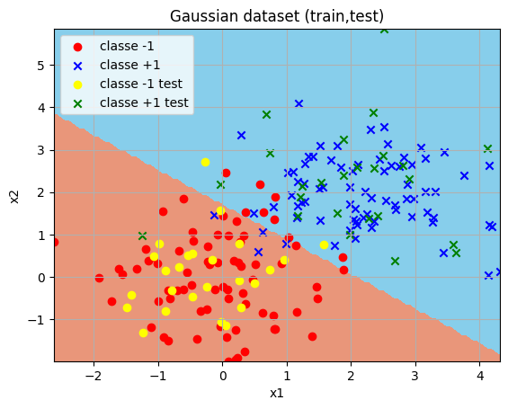

```python
# Réinitialisation de la graine pour la mise au point (à enlever ensuite !)
np.random.seed(42)   # on prend 42 comme graine

# De même, les classes de Classifiers sont utilisables en mettant cl. devant leur nom:
# Création d'un perceptron
perceptronBiais = cl.ClassifierPerceptron(2, learning_rate=0.01, init=False, verbose=True)

print("Apprentissage:")
perceptronBiais.train(train_desc,train_label,nb_max=1000,verbose=True)

print(f"Accuracy Train:\t{perceptronBiais.accuracy(train_desc,train_label):1.4f}")
print(f"Accuracy Test:\t{perceptronBiais.accuracy(test_desc,test_label):1.4f}")

# Affichage de la frontière de séparation des classes
ut.plot_frontiere(X_gauss, Y_gauss,perceptronBiais,step=120)
ut.plot2DTrainTestSet(train_desc,train_label,test_desc,test_label, nom_dataset="Gaussian dataset (train,test)")
```

**[Q]** Comparer le nouveau résultat obtenu avec le précédent résultat obtenu avec le perceptron du TME3. Qu'en déduisez-vous ?

**[Q]** Pour étudier la convergence du perceptron, il faut garder une trace de tous les poids $w$ utilisés. Pour cela, ajouter à la classe `ClassifierPerceptron` un attribut de nom `__allw`, de type liste, qui est initialisé aux poids initiaux dans `__init__` par:

```
self.__allw =[self.__w.copy()] # stockage des premiers poids
```

cet attribut est ensuite à mettre jour pendant l'entraînement dans la fonction `train_step` du perceptron, **après chaque mise à jour des poids**.

**Remarque**: attention ! pour copier le vecteur $w$ penser à faire une copie profonde...

Ajouter aussi dans la classe un accesseur `get_allw()` pour récupérer la valeur de `allw`.

```
Classifier #3 (d2): Perceptron (biais) init (learning rate= 0.005) w= [0. 0. 0.]
train Classifier #3 (d2) - Perceptron w= [ 0.0188633, 0.0159639, 0.035] : 193 appels à train_step
```

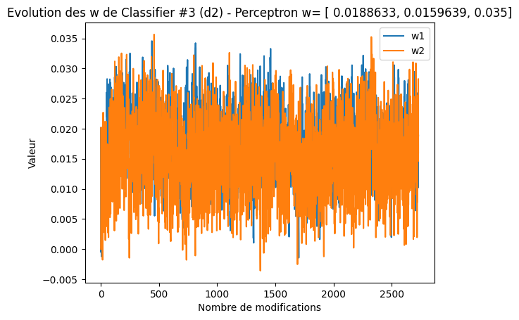

```python
# A utiliser une fois la classe ClassifierPerceptron modifiée par l'ajout de allw

# Paramètres pour le perceptron:
dim = 2
eps = 5e-3    # learning rate

# Réinitialisation de la graine pour la mise au point (à enlever ensuite !)
np.random.seed(42)   # on prend 42 comme graine

perceptron2 = cl.ClassifierPerceptron(dim, learning_rate=eps, init=True, verbose=True)

les_differences = perceptron2.train(train_desc,train_label,nb_max=1000,verbose=True)

# récupération de l'évolution des w au cours de l'apprentissage
# perceptron initialisé à 0
# si allw est sous forme de liste de couples [w1, w2], on doit la convertir en np.array pour la suite:
allw = np.array(perceptron2.get_allw())

# Tracé de l'évolution des w:
plt.figure()
plt.plot(allw[:,0]) # première coordonnée du vecteur poids: w1
plt.plot(allw[:,1]) # deuxième coordonnée du vecteur poids: w2
plt.title(f'Evolution des w de {perceptron2}')
plt.xlabel('Nombre de modifications')
plt.ylabel('Valeur')
plt.legend(['w1','w2'])

# Sauvegarde de la figure obtenue (décommenter la ligne ci-dessous et créer le sous-répertoire out/):
#plt.savefig('out/cvg.png')
```

## Une autre variante: le perceptron stabilisé

Une variante pour le classifieur perceptron est de modifier la condition utilisée pour la mise à jour des poids: celle-ci pouvant se faire quand $$f(\mathbf x_i) y_i < 1$$ avec $f(\mathbf x_i)$ est le **score** obtenu pour $x_i$.

L'idée sous-jacente est que pour faire la mise à jour, on veut que $f(\mathbf x_i)$ et $y_i$ soient du même signe **ET** que $f(\mathbf x_i)$ soit suffisamment grand (en valeur absolue).

Cette variante de perceptron est dite **stabilisée** car les points ne sont considérés bien classés que lorsque $f(\mathbf x_i) y_i \geq 1$. Dans le cas contraire, on met à jour les poids.

Dans cette variante, la mise à jour des poids doit alors tenir compte de ce changement de condition, on doit appliquer la mise à jour suivante: $$w = w +\epsilon (y_i- f(\mathbf x_i))x_i.$$

**[Q]** Dans notre implémentation, la stabilisation n'intervient que dans la fonction `train_step`, nous n'allons donc pas réécrire une nouvelle classe, mais simplement ajouter la possibilité d'utiliser la stabilisation en ajoutant un argument à la fonction `train_step` qui indiquera si on veut, ou pas, utiliser la stabilisation. La spécification de la fonction devient: def train_step(self, desc_set, label_set,stabilised=False): """ Réalise une unique itération sur tous les exemples du dataset donné en prenant les exemples aléatoirement. Arguments: - desc_set: array avec des descriptions - label_set: array avec les labels correspondants - stabilised: boolean pour dire si on veut la variante stabilisée (par défaut: False) """

Modifier votre fonction `train_step` en conséquence.

Comme `train_step` est appelé par la fonction `train`, il faut aussi modifier cette fonction:

```
        def train(self, desc_set, label_set, nb_max=100, seuil=0.001,stabilised=False,verbose=False):
            """ Apprentissage itératif du perceptron sur le dataset donné.
                Arguments:
                    - desc_set: array avec des descriptions
                    - label_set: array avec les labels correspondants
                    - nb_max (par défaut: 100) : nombre d'itérations maximale
                    - seuil (par défaut: 0.01) : seuil de convergence
                    - stabilised: boolean pour dire si on veut la variante stabilisée (par défaut: False)
                    - verbose (par défaut: False): affichage de messages d'information
                Retour: la fonction rend une liste
                    - liste des valeurs de norme de différences
            """
```

et transmettre lors de l'appel à `train_step` la valeur de ce nouvel argument.

```
Classifier #4 (d2): Perceptron (biais) init (learning rate= 0.005) w= [0. 0. 0.]
Apprentissage:
train Classifier #4 (d2) - Perceptron w= [ 0.791985, 0.681891, 1.61069] : 177 appels à train_step
Accuracy Train:	0.9333
Accuracy Test:	0.9200
```

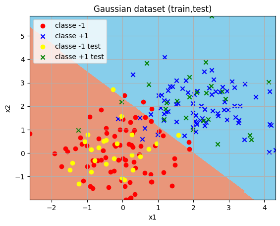

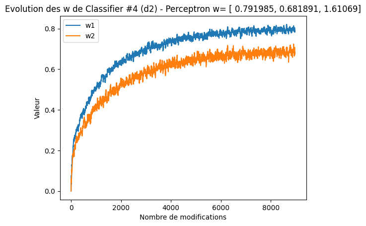

```python
np.random.seed(42)   # on prend 42 comme graine

# Paramètres pour le perceptron:
dim = 2
eps = 5e-3    # learning rate

# Création et entraînement du perceptron sur les données générées

perceptronStab = cl.ClassifierPerceptron(dim, learning_rate=eps, init=True,verbose=True)

print("Apprentissage:")
les_differences = perceptronStab.train(train_desc,train_label,nb_max=1000,stabilised=True,verbose=True)

print(f"Accuracy Train:\t{perceptronStab.accuracy(train_desc,train_label):1.4f}")
print(f"Accuracy Test:\t{perceptronStab.accuracy(test_desc,test_label):1.4f}")

# Affichage de la frontière de séparation des classes
ut.plot_frontiere(X_gauss, Y_gauss,perceptronStab,step=100)
ut.plot2DTrainTestSet(train_desc,train_label,test_desc,test_label, nom_dataset="Gaussian dataset (train,test)")

# récupération de l'évolution des w au cours de l'apprentissage
# perceptron initialisé à 0
# si allw est sous forme de liste de couples [w1, w2], on doit la convertir en np.array pour la suite:
allw = np.array(perceptronStab.get_allw())

# Tracé de l'évolution des w:
plt.figure()
plt.plot(allw[:,0]) # première coordonnée du vecteur poids: w1
plt.plot(allw[:,1]) # deuxième coordonnée du vecteur poids: w2
plt.title(f'Evolution des w de {perceptronStab}')
plt.xlabel('Nombre de modifications')
plt.ylabel('Valeur')
plt.legend(['w1','w2'])


# Sauvegarde de la figure obtenue (décommenter la ligne ci-dessous):
# et créer un répertoire out/ dans le répertoire tme04
# puis aller dans le répertoire `out` avec un navigateur de fichiers (ou par le terminal)
# pour visualiser l'image obtenue par :

# plt.savefig('out/cvg.png')
```

# Lien avec l'optimisation des fonctions de coût

Après ces rappels de code, nous entrons maintenant dans le vif du sujet !

L'évolution des poids du perceptron correspond en réalité à l'optimisation de la fonction coût suivante (cela est développé en cours):

$$ \mathcal C = \sum_{i=1}^N [1- f(\mathbf x_i) y_i]_+, \qquad \mbox{avec: } [\alpha]_+ = \left\{\begin{array}{ll} \alpha & \mbox{ si } \alpha >0\\ 0 & \mbox{ sinon } \end{array}\right.$$

Nous utilisons ici la version *stabilisée* du perceptron où les exemples ne sont bien classés que lorsque $f(\mathbf x_i) y_i>1$

Le perceptron est une simple descente de gradient.

Deux questions se posent alors :

1. Quelle est l'évolution de $\mathcal C$ au cours des itérations ?
2. Quel chemin de variations prennent les $w$ dans le cas 2D ?

**[Q]** Donner les instructions qui permettent de tracer l'évolution du coût $\mathcal{C}$ au cours des itérations lors de l'apprentissage précédent. Pour cela, vous utiliserez les valeurs de $w$ sauvegardées lors de l'apprentissage.

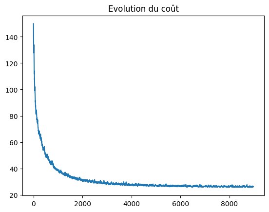

```python
# Toujours avec les mêmes données :
X = train_desc
Y = train_label

# on considère les poids de perceptron_biais généré dans une boite précédente:
allw = np.array(perceptronStab.get_allw())

#########################################################
# PARTIE A COMPLETER:

# C =  ...               ### A DECOMMENTER ET COMPLETER

#########################################################

plt.figure()
plt.plot(C)
plt.title('Evolution du coût')

# Sauvegarde de la figure obtenue (décommenter la ligne ci-dessous):
#plt.savefig('out/cost.png')
```

#### Nouvelles données et PerceptronTME3

Dans ce qui suit, on reprend le perceptron TME 3 car on veut modèle avec un biais nul pour n'avoir que 2 axes (les dimensions de $w$) dans la visualisation de l'évolution des poids.

Comme le perceptron avec biais, il est aussi nécessaire que ce perceptron TME3 :

- mémorise les valeurs de poids après chaque modification
- puisse aussi être stabilisé

**[Q]** En reprenant ce que vous avez fait pour le perceptron avec biais, modifier la classe `ClassifierPerceptronTME3` afin que les poids soient mémorisés au cours de l'entraînement, et ajouter l'option pour stabiliser ce modèle.

Comme le perceptron TME3 a un biais nul, on génère des données un peu plus faciles pour lui afin de faciliter la visualisation.

```
Base d'apprentissage: (200, 2) et 200 labels
Base de test: (100, 2) et 100 labels
```

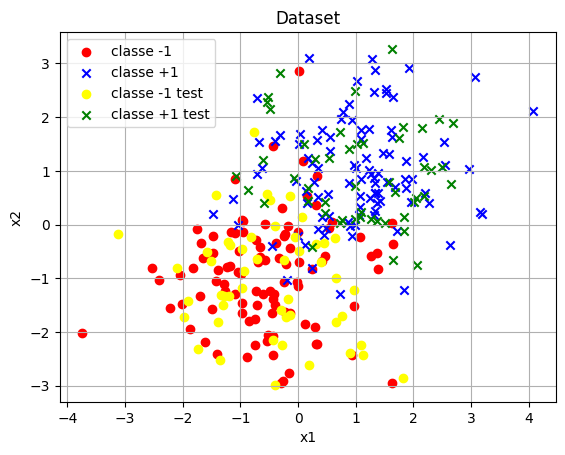

```python
np.random.seed(42)   # on prend 42 comme graine

# Génération d'un dataset gaussien avec 200 exemples au total
X_gauss2, Y_gauss2 = ut.genere_dataset_gaussian(np.array([1,1]) ,np.array([[1,0],[0,1]]), \
                                                       np.array([-0.5,-1]), np.array([[1,0],[0,1]]), \
                                                       150)

# Découpage en train/test du dataset gaussien
(train_X, train_Y), (test_X, test_Y) = ut.genere_train_test(X_gauss2, Y_gauss2,100,100)

print(f"Base d'apprentissage: {train_X.shape} et {len(train_Y)} labels")
print(f"Base de test: {test_X.shape} et {len(test_Y)} labels")

# Affichage :
ut.plot2DTrainTestSet(train_X, train_Y,test_X, test_Y)
```

```python
np.random.seed(42)   # on prend 42 comme graine

# Paramètres pour le perceptron:
dim = 2
eps = 5e-3    # learning rate

# Création et entraînement du perceptron sur les données générées (initialisation à 0)
perceptronTME3 = cl.ClassifierPerceptronTME3(dim, learning_rate=eps, init=True, verbose=True)

print("Apprentissage:")
les_differences = perceptronTME3.train(train_X,train_Y,nb_max=1000,stabilised=True,verbose=True)

print(f"Accuracy Train:\t{perceptronTME3.accuracy(train_X,train_Y):1.4f}")
print(f"Accuracy Test:\t{perceptronTME3.accuracy(test_X,test_Y):1.4f}")

# Affichage de la frontière de séparation des classes
ut.plot_frontiere(X_gauss2, Y_gauss2,perceptronTME3,step=100)
ut.plot2DTrainTestSet(train_X,train_Y,test_X,test_Y, nom_dataset="Gaussian dataset (train,test)")

# récupération de l'évolution des w au cours de l'apprentissage
# perceptron initialisé à 0
# si allw est sous forme de liste de couples [w1, w2], on doit la convertir en np.array pour la suite:
allw = np.array(perceptronTME3.get_allw())

# Tracé de l'évolution des w:
plt.figure()
plt.plot(allw[:,0]) # première coordonnée du vecteur poids: w1
plt.plot(allw[:,1]) # deuxième coordonnée du vecteur poids: w2
plt.title(f'Evolution des w de {perceptronTME3}')
plt.xlabel('Nombre de modifications')
plt.ylabel('Valeur')
plt.legend(['w1','w2'])
```

[output not shown]

**[Q]** Donner les instructions qui permettent de tracer l'évolution du coût $\mathcal{C}$ au cours des itérations lors de l'apprentissage de `perceptronTME3`.

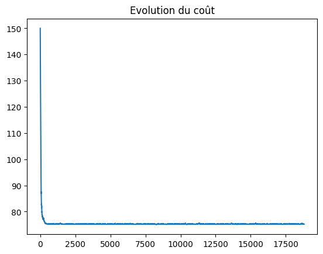

```python
# Toujours avec les mêmes données :
X = train_desc
Y = train_label

# on considère les poids de perceptron_biais généré dans une boite précédente:
allw = np.array(perceptronTME3.get_allw())

#########################################################
# PARTIE A COMPLETER:

# C =  ...               ### A DECOMMENTER ET COMPLETER

#########################################################


plt.figure()
plt.plot(C)
plt.title('Evolution du coût')
```

#### Evolution des poids dans l'espace des paramètres

Le code pour étudier l'évolution des poids durant l'apprentissage de `perceptronTME3`dans l'espace des paramères est presque entièrement donné ci-dessous... Sauf une ligne critique !

**Remarque**: il faut absolument comprendre la signification du code et de l'image produite.

Pour cela, regarder la documentation des fonctions

- `numpy.meshgrid` : https://numpy.org/doc/stable/reference/generated/numpy.meshgrid.html
- `numpy.linspace` : https://numpy.org/doc/stable/reference/generated/numpy.linspace.html
- `matplotlib.pyplot.scatter` : : https://matplotlib.org/stable/api/_as_gen/matplotlib.pyplot.scatter.html

```
bornes: [0.46936748 0.58931584] et [0. 0.]
```

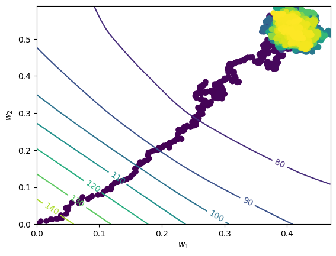

```python
# Evolution des poids dans l'espace des paramètres
# le code est presque entièrement donné... Sauf une ligne critique
# Il faut absolument comprendre la signification du code et de l'image produite
# -> On ne considère que les 2 premières dimensions des poids (w1, w2)

# on considère les poids de perceptron_biais généré dans une boite précédente:
allw = np.array(perceptronTME3.get_allw())

last = allw[-1,:]

# 0. Conserver que les 2 premières colonnes de allw:
allw_red = allw[:,0:2]
# 1. Construction d'une grille de 'toutes' les valeurs possibles de w dans les bornes de allw
mmax=allw_red.max(0)
mmin=allw_red.min(0)

print(f"bornes: {mmax} et {mmin}")
x1grid,x2grid=np.meshgrid(np.linspace(mmin[0],mmax[0],30),np.linspace(mmin[1],mmax[1],30))
grid=np.hstack((x1grid.reshape(x1grid.size,1),x2grid.reshape(x2grid.size,1)))

# 2. Evaluation du cout pour toutes ces solutions potentielles

#########################################################
# PARTIE A COMPLETER:
# construction de res = calcul du cout du perceptron pour tous les couples
# (w1,w2) définis dans grid

# res = # <-------------------------- A COMPLETER  ---------------

#########################################################

# remise en forme de res
res=res.reshape(x1grid.shape)

fig, ax = plt.subplots() # pour 1 et 2
ax.set_xlabel('$w_1$')
ax.set_ylabel('$w_2$')
CS = ax.contour(x1grid,x2grid,res)
ax.clabel(CS, inline=1, fontsize=10)
# ajoute de la couleur: jaune = plus grande itération
ax.scatter(allw[:,0], allw[:,1], c=np.arange(len(allw)))

# Sauvegarde de la figure obtenue (décommenter la ligne ci-dessous):
#plt.savefig("out/espace_param.png")
```

La solution initiale $w=[0,0]$ correspond à un coût élevé. L'algorithme du perceptron fait évoluer les poids du modèle pour aller dans une zone de l'espace où le coût est moindre.

**ATTENTION** à ne pas confondre l'espace de représentation des points (où les axes sont $X_1,X_2$) et l'espace de représentation des paramètres (ici, où chaque point correspond à un classifieur associé à un niveau de coût).

# Validation Croisée

Dans le but d'évaluer un classifier, nous avons vu dans le TME 3 qu'il était important de posséder un ensemble de données de test, différent de l'ensemble d'apprentissage.

Nous allons voir maintenant une méthode encore plus efficace pour bien évaluer un algorithme.

La procédure de la **validation croisée** (ou *cross validation*) est au centre de la plupart des applications de machine learning: il est temps pour nous de travailler sur une implémentation.

L'idée est de concevoir la fonction suivante:

```
Xapp,Yapp,Xtest,Ytest = crossval(X, Y, n_iterations, iteration)
```

- `X, Y` sont les données du dataset mélangées aléatoirement (**ATTENTION:** **on ne mélange pas physiquement les données, mais seulement leurs indices**)
- `n_iterations` est le nombre d'ensembles de test au total.
- `iteration` est l'itération concernée: on ne renvoit pas les mêmes données en fonction des itérations.

Après séparation des indices en `n_iterations` groupes, isoler 1 groupe pour le test et les autres pour l'apprentissage.

**Remarques:**

- on fait l'hypothèse que le dataset (`X`, `Y`) garde toujours le même ordre entre 2 appels de `crossval` successif avec des valeurs d'itération différentes.
- cette fonction ne doit pas mélanger les données du dataset fourni (qui doit être mélangé au préalable), elle sert juste à extraire de ce dataset 2 sous-datasets: un dataset d'apprentissage (`Xapp`, `Yapp`) et un dataset de test (`Xtest`, `Ytest`).
- elle extrait les datasets demandés comme suit:
  - le dataset de test pour l'itération $i$ contient les exemples du dataset $X$ dont les indices vont de $i\frac{len(X)}{n}$ à $(i+1)\frac{len(X)}{n}-1$ (avec $n$ le nombre d'itérations `n_iterations` fixé).
  - le dataset d'apprentissage pour l'itération $i$ contient les exemples du dataset $X$ contient les exemples qui ne sont pas dans le dataset de test.

**Note** Pour mélanger les données au départ, avant le premier appel de `crossval`, vous pouvez utiliser les commandes suivantes:

```
index = np.random.permutation(len(X)) # mélange des index
Xm = X[index]
Ym = Y[index]

# check: malgré le mélange, les données doivent être les mêmes
plt.figure()
plt.scatter(Xm[Ym==1,0], Xm[Ym==1,1], c='b')
plt.scatter(Xm[Ym==-1,0], Xm[Ym==-1,1], c='r')
```

**[Q]** Donner la définition de la fonction `crossval` telle qu'elle est décrite.

```python
def crossval(X, Y, n_iterations, iteration):
    #############
    # A COMPLETER
    #############
    return Xapp, Yapp, Xtest, Ytest
```

Regarder l'exemple d'utilisation suivant, sur un dataset jouet, pour comprendre comment sont pris les exemples à chaque appel différent.

```python
# Pour vérifier que le traitement est bien réalisé et que tout marche bien
# en particulier (très important !) que le lien entre descriptions X et classes Y n'est pas perdu,
# on peut regarder ce qui se passe si X et Y sont les mêmes:

N = 24  # Nombre d'exemples dans le dataset
Xjouet = np.array([100+i for i in range(0,N)])
Yjouet = Xjouet  # Yjouet est identique à Xjouet

niter = 4
for i in range(niter):
    Xapp,Yapp,Xtest,Ytest = crossval(Xjouet, Yjouet, niter, i)
    print("========== ITERATION : ",i," ==========")
    print(" Xapp=", Xapp.T,"\n","Yapp=", Yapp,"\n","Xtest=",Xtest.T,"\n","Ytest=", Ytest)


print("\n*********************\nEt on peut rappeler la fonction avec 0 par exemple: ")
Xapp,Yapp,Xtest,Ytest = crossval(Xjouet, Yjouet, niter, 0)
print(" Xapp=", Xapp.T,"\n","Yapp=", Yapp,"\n","Xtest=",Xtest.T,"\n","Ytest=", Ytest)
```

```
========== ITERATION :  0  ==========
 Xapp= [106 107 108 109 110 111 112 113 114 115 116 117 118 119 120 121 122 123]
 Yapp= [106 107 108 109 110 111 112 113 114 115 116 117 118 119 120 121 122 123]
 Xtest= [100 101 102 103 104 105]
 Ytest= [100 101 102 103 104 105]
========== ITERATION :  1  ==========
 Xapp= [100 101 102 103 104 105 112 113 114 115 116 117 118 119 120 121 122 123]
 Yapp= [100 101 102 103 104 105 112 113 114 115 116 117 118 119 120 121 122 123]
 Xtest= [106 107 108 109 110 111]
 Ytest= [106 107 108 109 110 111]
========== ITERATION :  2  ==========
 Xapp= [100 101 102 103 104 105 106 107 108 109 110 111 118 119 120 121 122 123]
 Yapp= [100 101 102 103 104 105 106 107 108 109 110 111 118 119 120 121 122 123]
 Xtest= [112 113 114 115 116 117]
 Ytest= [112 113 114 115 116 117]
========== ITERATION :  3  ==========
 Xapp= [100 101 102 103 104 105 106 107 108 109 110 111 112 113 114 115 116 117]
 Yapp= [100 101 102 103 104 105 106 107 108 109 110 111 112 113 114 115 116 117]
 Xtest= [118 119 120 121 122 123]
 Ytest= [118 119 120 121 122 123]

Et on peut rappeler la fonction avec 0 par exemple:
 Xapp= [106 107 108 109 110 111 112 113 114 115 116 117 118 119 120 121 122 123]
 Yapp= [106 107 108 109 110 111 112 113 114 115 116 117 118 119 120 121 122 123]
 Xtest= [100 101 102 103 104 105]
 Ytest= [100 101 102 103 104 105]
```

**[Q]** En fait, pour faire les choses correctement, il faut que la séparation des ensembles train/test respecte la distribution des classes dans le dataset de départ. Ecrire la fonction `crossval_strat` qui effectue la même chose que la fonction précédente mais en respectant la distribution des classes. La solution passe par un découpage qui s'effectue par classe.

```python
# code de la validation croisée (version qui respecte la distribution des classes)

def crossval_strat(X, Y, n_iterations, iteration):
    #############
    # A COMPLETER
    #############
    return Xapp, Yapp, Xtest, Ytest
```

```python
# Exemple d'utilisation avec un dataset jouet (1 Dimension)
N = 24  # Nombre d'exemples dans le dataset
Xtoy = np.array([100+i for i in range(0,N)])
Ytoy = np.array([-1]*(N//2) + [1]*(N//2))

niter = 3
for i in range(niter):
    Xapp,Yapp,Xtest,Ytest = crossval_strat(Xtoy, Ytoy, niter, i)
    print("========== ITERATION : ",i," ==========")
    print(" Xapp=", Xapp.T,"\n","Yapp=", Yapp,"\n","Xtest=",Xtest.T,"\n","Ytest=", Ytest)
```

```
========== ITERATION :  0  ==========
 Xapp= [104 105 106 107 108 109 110 111 116 117 118 119 120 121 122 123]
 Yapp= [-1 -1 -1 -1 -1 -1 -1 -1  1  1  1  1  1  1  1  1]
 Xtest= [100 101 102 103 112 113 114 115]
 Ytest= [-1 -1 -1 -1  1  1  1  1]
========== ITERATION :  1  ==========
 Xapp= [100 101 102 103 108 109 110 111 112 113 114 115 120 121 122 123]
 Yapp= [-1 -1 -1 -1 -1 -1 -1 -1  1  1  1  1  1  1  1  1]
 Xtest= [104 105 106 107 116 117 118 119]
 Ytest= [-1 -1 -1 -1  1  1  1  1]
========== ITERATION :  2  ==========
 Xapp= [100 101 102 103 104 105 106 107 112 113 114 115 116 117 118 119]
 Yapp= [-1 -1 -1 -1 -1 -1 -1 -1  1  1  1  1  1  1  1  1]
 Xtest= [108 109 110 111 120 121 122 123]
 Ytest= [-1 -1 -1 -1  1  1  1  1]
```

**Remarque**: il est important, avant d'utiliser `crossval` ou `crossval_strat` de **mélanger le dataset**. Ce mélange aléatoire doit être fait une seule fois avant le premier appel de la fonction (et jamais entre 2 appels).

```python
np.random.seed(42)   # on prend 42 comme graine

# Exemple d'utilisation avec un dataset jouet (1 Dimension)
N = 24  # Nombre d'exemples dans le dataset
Xtoy = np.array([100+i for i in range(0,N)])
Ytoy = np.array([-1]*(N//2) + [1]*(N//2))
index = np.random.permutation(len(Xtoy)) # mélange des index
XtoyMelange = Xtoy[index]
YtoyMelange = Ytoy[index]

niter = 3
for i in range(niter):
    Xapp,Yapp,Xtest,Ytest = crossval_strat(XtoyMelange, YtoyMelange, niter, i)
    print("========== ITERATION : ",i," ==========")
    print(" Xapp=", Xapp.T,"\n","Yapp=", Yapp,"\n","Xtest=",Xtest.T,"\n","Ytest=", Ytest)
```

```
========== ITERATION :  0  ==========
 Xapp= [101 105 102 112 115 103 104 122 117 120 123 107 110 114 119 106]
 Yapp= [-1 -1 -1  1  1 -1 -1  1  1  1  1 -1 -1  1  1 -1]
 Xtest= [108 100 111 109 116 118 113 121]
 Ytest= [-1 -1 -1 -1  1  1  1  1]
========== ITERATION :  1  ==========
 Xapp= [108 116 100 118 111 109 113 121 104 120 123 107 110 114 119 106]
 Yapp= [-1  1 -1  1 -1 -1  1  1 -1  1  1 -1 -1  1  1 -1]
 Xtest= [101 105 102 103 112 115 122 117]
 Ytest= [-1 -1 -1 -1  1  1  1  1]
========== ITERATION :  2  ==========
 Xapp= [108 116 100 118 111 109 113 101 121 105 102 112 115 103 122 117]
 Yapp= [-1  1 -1  1 -1 -1  1 -1  1 -1 -1  1  1 -1  1  1]
 Xtest= [104 107 110 106 120 123 114 119]
 Ytest= [-1 -1 -1 -1  1  1  1  1]
```

## Tests de la procédure de validation croisée

Sur des données réelles et sur des données jouets

```python
np.random.seed(42)   # on prend 42 comme graine
# test sur les données jouet X, Y supposées pré-existantes

index = np.random.permutation(len(X)) # mélange des index
Xm = X[index]
Ym = Y[index]
niter = 10
perf = []

# Paramètres pour le perceptron:
dim = 2
eps = 1e-3    # learning rate
poids_0 = True   # valeur initiale des poids à 0

for i in range(niter):
    Xapp,Yapp,Xtest,Ytest = crossval(Xm, Ym, niter, i)
    perceptron4 = cl.ClassifierPerceptron(dim, eps, poids_0)
    perceptron4.train(Xapp, Yapp,stabilised=True)
    perf.append(perceptron4.accuracy(Xtest, Ytest))

print(f"Performances obtenues: {perf}")
```

```
Performances obtenues: [0.8666666666666667, 0.9333333333333333, 1.0, 0.8, 0.9333333333333333, 1.0, 1.0, 0.8666666666666667, 0.8666666666666667, 0.9333333333333333]
```

**[Q]** Tester la validation croisée sur les données USPS.

**Remarque:** pour utiliser les données USPS, il vous faut

- soit créer un lien symbolique (cf. TME 3) vers le sous-répertoire `data` du TME 2 qui contient le fichier `usps.pkl` du TME 2
- soit modifier le nom du fichier dans la commande `open` du code ci-dessous en mettant le chemin d'accès vers l'endroit où se trouve votre fichier `usps.pkl`

```python
# test sur les données USPS
import pickle as pkl

data = pkl.load(open('data/usps.pkl', 'rb'))
Xu = np.array(data['X_train'], dtype=float) # conversion de type pour une meilleure compatibilité
Yu = np.array(data['Y_train'], dtype=float)

# Création d'un sous groupe de données
c1 = 4  # ---> sera associée au label +1
c2 = 6  # ---> sera associée au label -1
X12 = Xu[(Yu==c1) | (Yu==c2)]
Y12 = np.where(Yu[(Yu==c1) | (Yu==c2)]==c1, 1, -1)

np.random.seed(42)   # on prend 42 comme graine

# Paramètres pour le perceptron:
dim = X12.shape[1]   # la dimension est donnée par le nombre de colonnes de X12
eps = 1e-3    # learning rate
poids_0 = True   # valeur initiale des poids à 0

# Nombre d'itérations voulues pour la validation croisée:
nb_iter = 10
# Liste pour stocker les taux de bonne classification à chaque itération
perf = []

# ######################## A COMPLETER CI-DESSOUS
# 1) mélanger des exemples

# 2) réaliser une validation croisée complète

#################################################
```

```python
# Résultat final:
print("Performances obtenues : ",perf)
```

```
Performances obtenues :  [0.972972972972973, 0.990990990990991, 0.990990990990991, 1.0, 0.990990990990991, 0.990990990990991, 0.990990990990991, 0.990990990990991, 1.0, 0.990990990990991]
```

**[Q]** Pour évaluer un classifieur, on regarde la moyenne et l'écart type de son taux de bonne classification lors d'une validation croisée.

Ecrire la fonction `analyse_perfs` qui prend en argument une liste de nombres réels (non vide) et renvoie le tuple constitué de la moyenne et de l'écart type de ces nombres.

**Remarque**: l'écart type donne une information sur la "robustesse" du modèle. Plus il est grand, est plus cela signifie que la performance du classifieur dépend du jeu d'apprentissage qui a servi à le construire.

```python
# ------------------------ A COMPLETER
def analyse_perfs(L):
    """ L : liste de nombres réels non vide
        rend le tuple (moyenne, écart-type)
    """
    raise NotImplementedError("Vous devez implémenter cette fonction !")
```

```python
# Sur les résultats obtenus dans la boîte précédemment:
analyse_perfs(perf)
```

```
(0.990990990990991, 0.006978348371544882)
```

**[Q]** Quelle information apporte ici l'écart type ?

## Etude des classifieurs knn, perceptron et perceptron biais

**[Q]** Comparer les performances sur le jeu de données USPS (par exemple, en prenant le label 1 et le label 7 pour avoir 2 classes), par une validation croisée en 10 groupes, de tous les classifieurs que vous avez déjà implémentés. Que peut-on en conclure ?

```
Avec KPPV (k=5):
	Perf obtenues :  ['1.0', '1.0', '1.0', '1.0', '0.9926', '0.9853', '0.9926', '0.9853', '0.9926', '0.9926']
	Moyenne: 0.9941 ecart: 0.0055024
Avec classifieur linéaire random:
	Perf obtenues :  ['0.6324', '0.3309', '0.8529', '0.04412', '0.03676', '0.7574', '0.8162', '0.8529', '0.5735', '0.6544']
	Moyenne: 0.55515 ecart: 0.2971
Avec perceptron (init aléatoire):
	Perf obtenues :  ['1.0', '1.0', '1.0', '1.0', '1.0', '0.9926', '1.0', '0.9853', '0.9926', '1.0']
	Moyenne: 0.99706 ecart: 0.0048774
Remarque: les résultats sont donnés à titre indicatifs car ils sont dépendants des choix aléatoires...
```

# Plus loin avec le multi-classes

Le perceptron est un algorithme fondamentalement bi-classes: il est même lié à la manière dont sont encodées les étiquettes $\{+1,-1\}$. La plupart des problèmes réels sont pourtant multi-classes (e.g. USPS). Si cet algorithme a pu rester aussi classique, c'est qu'il existe un moyen d'étendre un classifieur binaire en une extension multi-classes simple et efficace: le *un-contre-tous* (ou *One-Against-All* en anglais):

*(si l'image ci-dessous ne s'affiche pas, aller la voir dans le répertoire ressources)*

[figure not shown]

Dans l'approche *un-contre-tous* l'idée est d'apprendre autant de classifieurs binaires que de classes.

Dans l'exemple ci-dessus, cela donne:

1. Traitement de la classe 0
2. redéfinition de: $$Y_{tmp} = \left\{ \begin{array}{ll} 1 & \text{ si } Y = 0\\ -1 & \text{ si } Y \neq 0\\ \end{array} \right. $$
3. apprentissage de $f_0$ sur $X,Y_{tmp}$
4. Traitement de la classe 1
5. redéfinition de: $$Y_{tmp} = \left\{ \begin{array}{ll} 1 & \text{ si } Y = 1\\ -1 & \text{ si } Y \neq 1\\ \end{array}\right. $$
6. apprentissage de $f_1$ sur $X,Y_{tmp}$
7. etc...

En inférence, lorsqu'un nouveau point $\mathbf x$ est présenté il faut:

1. calculer $score = [f_0(\mathbf x), f_1(\mathbf x), \ldots f_C(\mathbf x)]$
2. prédire $\text{argmax}_c (score)$

Pour implémenter cela, on ne va pas définir une version multi-classe pour chaque classifieur binaire que l'on a écrit, cela ne serait pas de la programmation efficace... On va définir un nouveau classifieur générique multi-classes qui utilisera un classifieur binaire (en POO, on va se baser sur le *pattern composite*) en respectant le schéma suivant:

1. `ClassifierMultiOAA` prend un classifieur binaire en argument lors de la création. Il initialise une liste vide de classifieurs.
2. Dans la méthode `train`, penser à cloner le classifeur de référence `nCl` fois (autant de classifieurs que de classes dans la base d'apprentissage). Il faut utiliser la méthode `deepcopy` du module standard python `copy`
3. Dans un boucle for, redéfinir les étiquettes $ytmp$ et apprendre des classifieurs binaires
4. Dans `score` faire appel aux méthodes `score` des classifieurs binaires et stocker les résultats
5. Dans `predict` renvoyer l'argmax des scores.  
   **Note:** en faisant cette opération, on fait l'hypothèse que les étiquettes sont définies sur $[0,nCl]$. Pour lever cette hypothèse, il faudrait stocker les classes et convertir le résultat de argmax.

**Important:** La fonction `accuracy` de la classe mère doit être compatible avec les définitions précédentes... Par exemple:

```
def accuracy(self, desc_set, label_set):
        yhat = np.array([self.predict(x) for x in desc_set])
        return np.where(label_set == yhat, 1., 0.).mean()
```

**Attention:** on fait ici l'hypothèse que l'on ne considère que des classes numérotées de $0$ à $9$, comme celles dans USPS. Ainsi, le premier classifieur reconnaît la classe $0$ contre toutes les autres, le deuxième classifieur reconnaît la classe $1$ contre les autres, etc. Pour une solution plus générale, la fonction `predict` ne devra pas rendre l'indice du maximum (argmax) mais la classe qui correspond à ce maximum.

```python
# Donner la définition de la classe ClassifierMultiOAA

# Vous pouvez avoir besoin d'utiliser la fonction deepcopy de la librairie standard copy:
import copy


# ------------------------ A COMPLETER :

class ClassifierMultiOAA(cl.Classifier):
    """ Classifieur multi-classes
    """
    def __init__(self, cl_bin):
        """ Constructeur de Classifier
            Argument:
                - input_dimension (int) : dimension de la description des exemples (espace originel)
                - cl_bin: classifieur binaire positif/négatif
            Hypothèse : input_dimension > 0
        """
        raise NotImplementedError("Vous devez implémenter cette fonction !")


    def train(self, desc_set, label_set):
        """ Permet d'entrainer le modele sur l'ensemble donné
            réalise une itération sur l'ensemble des données prises aléatoirement
            desc_set: ndarray avec des descriptions
            label_set: ndarray avec les labels correspondants
            Hypothèse: desc_set et label_set ont le même nombre de lignes
        """
        raise NotImplementedError("Vous devez implémenter cette fonction !")


    def score(self,x):
        """ rend le score de prédiction sur x (valeur réelle)
            x: une description
        """
        raise NotImplementedError("Vous devez implémenter cette fonction !")

    def predict(self, x):
        """ rend la prediction sur x (soit -1 ou soit +1)
            x: une description
        """
        raise NotImplementedError("Vous devez implémenter cette fonction !")
```

```python
# opération assez coûteuse sur toutes les données !
# A faire dans une boite séparée

index = np.random.permutation(len(Yu))
Xm = Xu[index]
Ym = Yu[index]
```

```python
# validation croisée en multi-classes

# ------------------------ A COMPLETER :
niter = 10   # nombre d'itérations
perf_T = []  # accuracies sur la base d'apprentissage
perf_A = []  # accuracies sur la base de test

print("Attention: l'exécution peut prendre du temps !")
print("\nPerf A (apprentissage): ",perf_A)
print("\nPerf T (test) : ",perf_T)
#####################

###### A COMPLETER

#####################
print("\nPerformance A (apprentissage): ",perf_A)
print("\nPerferformance T (test) : ",perf_T)
```

```
Attention: l'exécution peut prendre du temps !
Itération 1: taille base apprentissage=  5610 taille base de test= 619
Itération 2: taille base apprentissage=  5610 taille base de test= 619
Itération 3: taille base apprentissage=  5610 taille base de test= 619
Itération 4: taille base apprentissage=  5610 taille base de test= 619
Itération 5: taille base apprentissage=  5610 taille base de test= 619
Itération 6: taille base apprentissage=  5610 taille base de test= 619
Itération 7: taille base apprentissage=  5610 taille base de test= 619
Itération 8: taille base apprentissage=  5610 taille base de test= 619
Itération 9: taille base apprentissage=  5610 taille base de test= 619
Itération 10: taille base apprentissage=  5610 taille base de test= 619

Performance A (apprentissage):  [0.9761140819964349, 0.9812834224598931, 0.9798573975044563, 0.9745098039215686, 0.9777183600713012, 0.9732620320855615, 0.9711229946524064, 0.9786096256684492, 0.9807486631016042, 0.9761140819964349]

Perferformance T (test) :  [0.9434571890145396, 0.9273021001615509, 0.9305331179321487, 0.9208400646203554, 0.9273021001615509, 0.9159935379644588, 0.9337641357027464, 0.9240710823909531, 0.9369951534733441, 0.9176090468497576]
```

## Toujours plus loin...

**[Q]** Comparer à nouveau les performances de vos classifieurs sur le jeu de données USPS, par une validation croisée en 10 groupes, mais cette fois-ci en traitant le problème comme un problème multi-classes.